# ice_cream_example

# Read in the data

```r
ice_cream <- read.csv("https://raw.githubusercontent.com/katiesevans/IGP_biostatistics/main/data/ice_cream.csv")

DT::datatable(ice_cream)
```

|  | id | female | ice_cream | video | puzzle |
| --- | --- | --- | --- | --- | --- |
| 1 | 70 | 0 | 2 | 47 | 57 |
| 2 | 121 | 1 | 1 | 63 | 61 |
| 3 | 86 | 0 | 3 | 58 | 31 |
| 4 | 141 | 0 | 3 | 53 | 56 |
| 5 | 172 | 0 | 1 | 53 | 61 |
| 6 | 113 | 0 | 1 | 63 | 61 |
| 7 | 50 | 0 | 1 | 53 | 61 |
| 8 | 11 | 0 | 1 | 39 | 36 |
| 9 | 84 | 0 | 1 | 58 | 51 |
| 10 | 48 | 0 | 1 | 50 | 51 |

[output cut: 190 more lines]

# Lecture 09

## Nonparametric tests

Split the original population of individuals into males and females. Perform a statistical analysis to determine if males are more likely to score higher on the puzzle than females.

What type of test is most appropriate here and why?

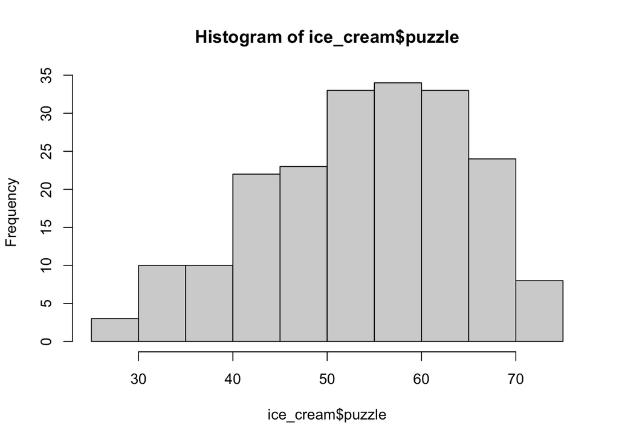

```r
hist(ice_cream$puzzle)
```

```r
print("Because the puzzle data is not normally distributed, it is best to use a nonparametric test to compare two samples like the Wilcoxon-Mann-Whitney U test.")
```

```
## [1] "Because the puzzle data is not normally distributed, it is best to use a nonparametric test to compare two samples like the Wilcoxon-Mann-Whitney U test."
```

Perform the analysis suggested above. What is the conclusion?

```r
# split into two populations, male and female
males <- ice_cream %>%
    dplyr::filter(female == 0)

females <- ice_cream %>%
    dplyr::filter(female == 1)

# easy way - we can use wilcox.test for independent samples!
wilcox.test(males$puzzle, females$puzzle)
```

```
##
##  Wilcoxon rank sum test with continuity correction
##
## data:  males$puzzle and females$puzzle
## W = 4735, p-value = 0.5795
## alternative hypothesis: true location shift is not equal to 0
```

```r
print("Our data suggest that there is no difference in puzzle scores between males and females (P = 0.57)")
```

```
## [1] "Our data suggest that there is no difference in puzzle scores between males and females (P = 0.57)"
```

Does our data support the hypothesis that students scored the same on the puzzle and the video game?

What is the null and alternative hypothesis?

```r
print("H0: The students scored the same on the puzzle and the video (i.e. puzzle - video = 0)")
```

```
## [1] "H0: The students scored the same on the puzzle and the video (i.e. puzzle - video = 0)"
```

```r
print("HA: The students did not score the same on the puzzle and the video (i.e. puzzle - video != 0)")
```

```
## [1] "HA: The students did not score the same on the puzzle and the video (i.e. puzzle - video != 0)"
```

First, use the sign test to get a rough estimate.

```r
# sign test - manually
# what is the difference in puzzle and video scores?
diff <- ice_cream$puzzle - ice_cream$video

# how many positive values?
pos <- sum(diff > 0)

# how many negative values?
neg <- sum(diff < 0)

# NOTE! cant just do 200 - pos... why?
n <- length(diff[diff != 0])

# binomial distribution: choose smaller of pos/neg values
# n = 191, p = 0.5
pbinom(neg, n, 0.5)
```

```
## [1] 0.1234548
```

```r
print("With a p-value of 0.123, we fail to reject the null hypothesis and conclude that students did not score differently on the puzzle and video scores")
```

```
## [1] "With a p-value of 0.123, we fail to reject the null hypothesis and conclude that students did not score differently on the puzzle and video scores"
```

Now, repeat the same test with the Wilcoxon signed-rank test. Since this test uses both rank and sign, it will likely give us a more appropriate estimate of the p-value.

```r
# repeat with wilcox test - paired samples (video and puzzle)
wilcox.test(ice_cream$puzzle, ice_cream$video, paired = T)
```

```
##
##  Wilcoxon signed rank test with continuity correction
##
## data:  ice_cream$puzzle and ice_cream$video
## V = 10292, p-value = 0.1418
## alternative hypothesis: true location shift is not equal to 0
```

```r
print("In this example, the sign test and the signed-rank test provide very similar results!")
```

```
## [1] "In this example, the sign test and the signed-rank test provide very similar results!"
```

## Bonus: Randomization

We talked about boot-strapping confidence intervals in lecture today and we wrote some code to do that… but what if we want to turn that into a function so we can change the confidence level or the data? Try to turn this code into a function:

```r
# generate random variable x
x <- rnorm(100)

# create variable to hold permutation means
perm_means <- c()
# do 10,000 permutations
for(i in 1:10000) {
    # sample from x with replacement (perm is same size as x)
    perm <- sample(x, replace = T)
    # calcualte mean and add to perm_means
    perm_means <- c(perm_means, mean(perm))
}

# get the middle 95% of the mean of the perms distribution
quantile(perm_means, c(0.025, 0.975))
```

```
##       2.5%      97.5%
## -0.2293048  0.1804231
```